# locally_stationary_autoregressive_model

Kousuke Kikuchi

June 23, 2015

# 8. 局所定常ARモデル

- 非定常な時系列データに対するARモデルを構築する際に、最も簡単な手法
- 時間区間を分割して、各区間では定常とし、近似的に定常時系列とみなす
- TSSSの関数だとlsar1（8.2）とlsar2（8.3）

### 8.1 局所定常ARモデル

- 局所定常時系列
  - 時系列全体として定常ではないが、適当な区間に分割すると定常と見なせるもの
  - 局所定常時系列の解析には分割する区間の個数k、区間データ数Niが必要
  - 局所定常時系列の解析には、分点の個数と一、区間数を推定することが必要になる。
- 局所定常ARモデル（locally stationary AR model）
  - i番目の小区間を[$n_{i0}, n_{n1}$]とする際の$n_{i0}, n_{i1}$は以下の式で表される $n_{i0} = \sum\limits_{j=1}^{i-1}N_{j} + 1\\ n_{i1} = \sum\limits_{j=1}^{i}N_{j}$
  - j番目の小区間では、時系列ynがARモデルに従うものと仮定
  - 小区間ごとにARモデルと同様に尤度を計算する
  - 全体の対数尤度を求める
  - AICを求め、最小となる小区間の数、小区間の長さ、ARモデルの次数を探す

### 8.2 任意個の区間への自動分割

- 8.1で紹介した方法は計算量が莫大であるので、現実的ではない。
  - 区間数kと小区間の長さ[N1, Nk]をすべての可能な組み合わせに対してAICを計算するため
- あらかじめ最小分割の単位を定めておき、一定のルールに従って分析（教科書嫁）

### 8.3 変化時点の精密な推定

- 時系列がある区間の中で著しく確率構造が変化している時間を検出する方法
- ある区間で構造変化があったと仮定して、全体の時間列とその前後に区分した時間列のAICを計算すれば、評価が可能

### 補足

- この方法だと、地震波の変化をAICの一番小さい値を計算して検知することはできるが、徐々に変化していくと無理
- 急激な変化があった時にしか使えない
- 異常検出は次に行う状態空間モデルを用いるらしい。

### 実際にやってみる

```r
library(TSSS)
# data(package="TSSS") # libraryのデータの確認
data(MYE1F)
summary(MYE1F)
```

```
##    Min. 1st Qu.  Median    Mean 3rd Qu.    Max.
## -47.000  -3.250  -1.000  -1.117   1.000  42.000
```

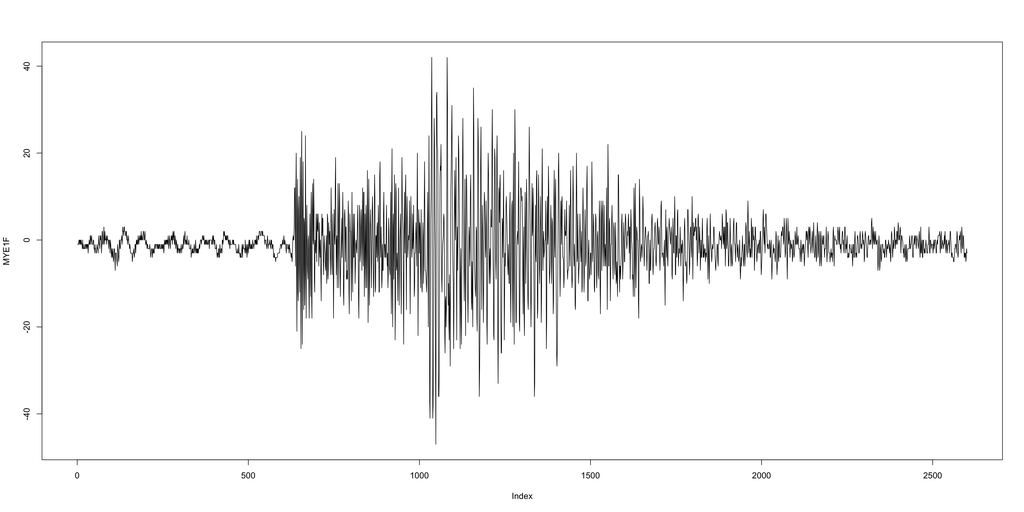

```r
plot(MYE1F, type="l")
```

### 8.2のやりかた

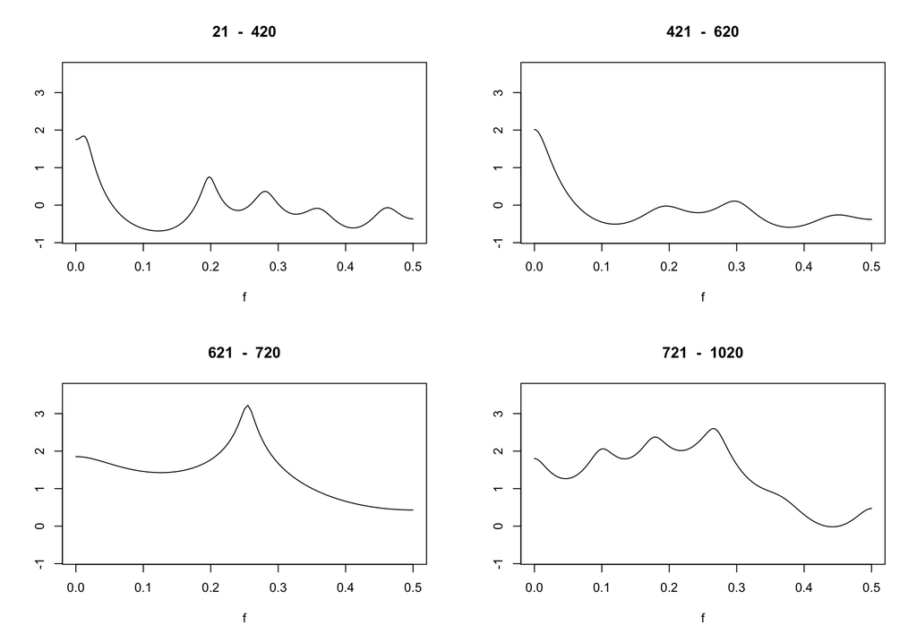

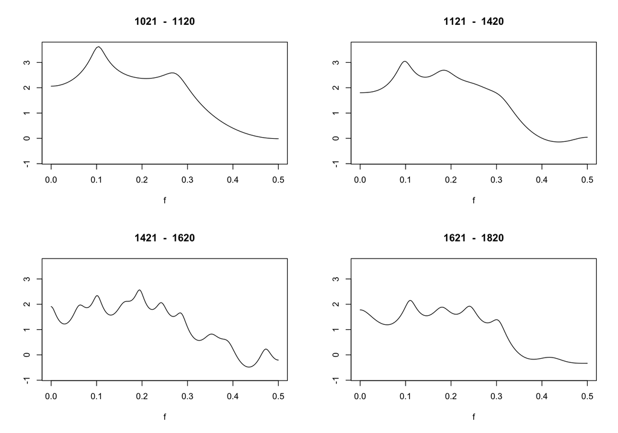

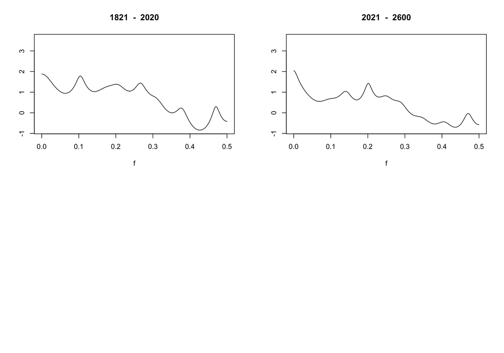

```
## <<< new data ( n = 21 --- 120 ) >>>
##  initial model : NS =   100
##      ms = 11   sds =  1.037628e+00   aics =      311.481
##
##
## <<< new data ( n = 121 --- 220 ) >>>
##  switched model : ( nf = 100,  ns = 100 )
##   ms = 9   sds =  7.739749e-01   aics =      589.648
##  pooled model : ( np = 200 )
##   mp = 9   sdp =  9.580510e-01   aicp =      579.005
##
##  ***  pooled model accepted   ***
##
##
## <<< new data ( n = 221 --- 320 ) >>>
##  switched model : ( nf = 200,  ns = 100 )
##   ms = 4   sds =  7.967687e-01   aics =      850.073
##  pooled model : ( np = 300 )
##   mp = 12   sdp =  9.009082e-01   aicp =      846.058
##
##  ***  pooled model accepted   ***
##
##
## <<< new data ( n = 321 --- 420 ) >>>
##  switched model : ( nf = 300,  ns = 100 )
##   ms = 12   sds =  6.303133e-01   aics =     1109.691
##  pooled model : ( np = 400 )
##   mp = 12   sdp =  8.470585e-01   aicp =     1094.757
##
##  ***  pooled model accepted   ***
##
##
## <<< new data ( n = 421 --- 520 ) >>>
##  switched model : ( nf = 400,  ns = 100 )
##   ms = 5   sds =  8.139431e-01   aics =     1369.958
##  pooled model : ( np = 500 )
##   mp = 19   sdp =  8.390124e-01   aicp =     1371.174
##
##  ***  switched model accepted   ***
##
```

[output cut: 173 more lines]

```
##  switched model : ( nf = 400,  ns = 100 )
##   ms = 6   sds =  1.763799e+00   aics =     1892.751
##  pooled model : ( np = 500 )
##   mp = 19   sdp =  2.353815e+00   aicp =     1886.957
##
##  ***  pooled model accepted   ***
##
##
## <<< new data ( n = 2521 --- 2600 ) >>>
##  switched model : ( nf = 500,  ns = 80 )
##   ms = 4   sds =  2.056971e+00   aics =     2181.686
##  pooled model : ( np = 580 )
##   mp = 19   sdp =  2.339797e+00   aicp =     2179.006
##
##  ***  pooled model accepted   ***
```

```r
lsar1(MYE1F,  ns0 = 100) # ns0は区間に含まれる個数
```

### 8.3のやりかた

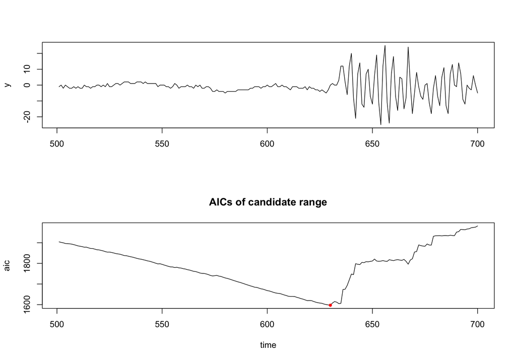

```
## $aic
##   [1] 1904.291 1901.718 1899.659 1896.419 1895.774 1894.837 1893.311
##   [8] 1890.878 1887.979 1884.849 1883.034 1881.189 1878.336 1878.578
##  [15] 1875.224 1872.329 1872.009 1868.996 1866.173 1865.269 1862.865
##  [22] 1860.430 1856.943 1854.588 1854.828 1852.793 1850.393 1847.507
##  [29] 1845.964 1844.259 1841.242 1837.840 1837.257 1834.570 1832.268
##  [36] 1830.089 1827.243 1824.338 1821.792 1820.187 1817.712 1815.263
##  [43] 1812.306 1810.455 1807.378 1804.221 1800.726 1797.546 1798.257
##  [50] 1795.236 1791.937 1788.782 1785.636 1783.001 1782.727 1779.709
##  [57] 1781.009 1778.304 1777.352 1774.322 1772.828 1769.569 1767.695
##  [64] 1764.596 1761.500 1760.166 1757.061 1753.341 1751.487 1751.045
##  [71] 1748.806 1745.563 1741.512 1739.093 1740.337 1741.668 1738.365
##  [78] 1736.558 1732.872 1729.471 1727.093 1724.088 1720.655 1717.132
##  [85] 1713.984 1710.625 1708.005 1704.579 1701.179 1697.584 1694.371
##  [92] 1690.952 1688.053 1684.535 1683.528 1680.253 1676.814 1675.011
```

[output cut: 21 more lines]

```r
# subintervalはここからここまでをとりあえず対象にしますよ
# candidateはここら辺に変化がありそうだ
# とりあえずP波の検出（値はグラフをみながら確認）
lsar2(MYE1F, subinterval=c(400, 800), candidate=c(500, 700))
```

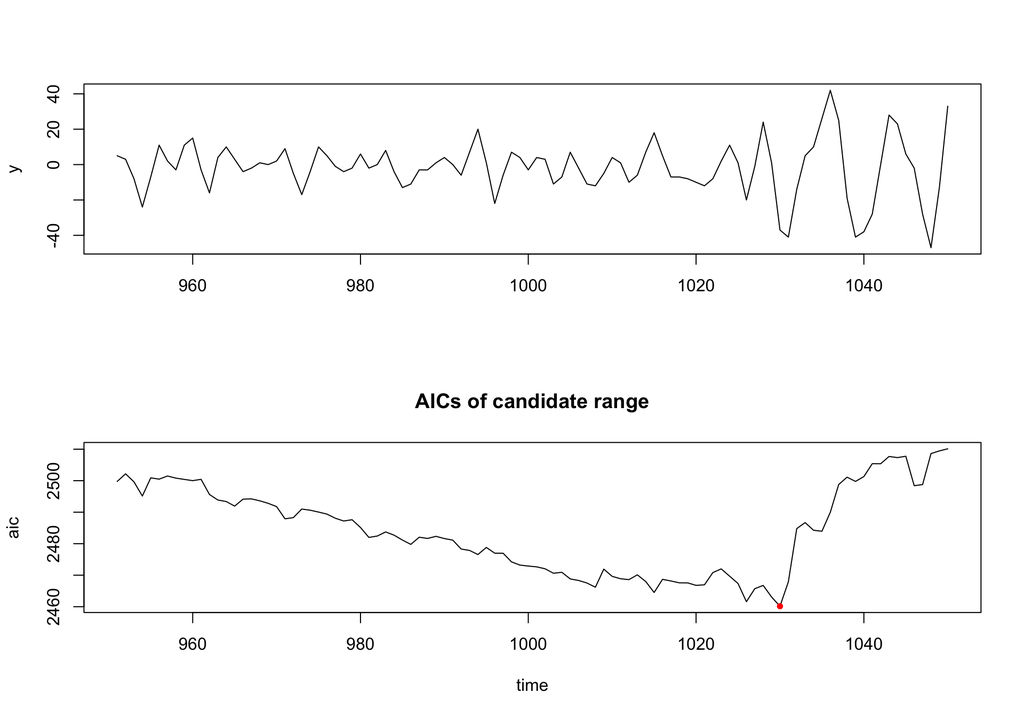

```
## $aic
##   [1] 2499.761 2502.184 2499.636 2495.121 2500.901 2500.492 2501.486
##   [8] 2500.811 2500.410 2500.011 2500.437 2495.620 2493.863 2493.385
##  [15] 2491.932 2494.143 2494.229 2493.613 2492.812 2491.776 2487.900
##  [22] 2488.287 2490.996 2490.638 2490.042 2489.396 2488.082 2487.203
##  [29] 2487.611 2485.143 2481.994 2482.432 2483.736 2482.710 2481.161
##  [36] 2479.778 2482.059 2481.674 2482.338 2481.635 2481.138 2478.306
##  [43] 2477.866 2476.562 2478.819 2476.993 2476.977 2474.233 2473.218
##  [50] 2472.906 2472.651 2472.042 2470.622 2470.928 2468.820 2468.332
##  [57] 2467.519 2466.187 2471.930 2469.632 2468.881 2468.594 2470.123
##  [64] 2467.999 2464.519 2468.690 2468.171 2467.582 2467.561 2466.780
##  [71] 2466.956 2470.838 2472.002 2469.682 2467.380 2461.589 2465.734
##  [78] 2466.757 2463.080 2460.156 2467.915 2484.804 2486.702 2484.272
##  [85] 2483.951 2489.989 2498.795 2501.116 2499.772 2501.308 2505.398
##  [92] 2505.375 2507.688 2507.330 2507.759 2498.408 2498.769 2508.605
##  [99] 2509.456 2510.127
##
## $aicmin
## [1] 2460.156
##
## $change.point
## [1] 1030
```

```r
# 変化点は630あたりで、AICは1597.215

# S波の検出
lsar2(MYE1F, subinterval=c(800, 1200), candidate=c(950, 1050))
```

```r
# 変化点は1030あたりで、AICは2460.156
```

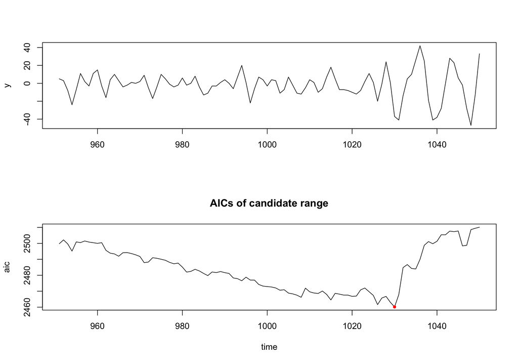

```
## $aic
##   [1] 2499.761 2502.184 2499.636 2495.121 2500.901 2500.492 2501.486
##   [8] 2500.811 2500.410 2500.011 2500.437 2495.620 2493.863 2493.385
##  [15] 2491.932 2494.143 2494.229 2493.613 2492.812 2491.776 2487.900
##  [22] 2488.287 2490.996 2490.638 2490.042 2489.396 2488.082 2487.203
##  [29] 2487.611 2485.143 2481.994 2482.432 2483.736 2482.710 2481.161
##  [36] 2479.778 2482.059 2481.674 2482.338 2481.635 2481.138 2478.306
##  [43] 2477.866 2476.562 2478.819 2476.993 2476.977 2474.233 2473.218
##  [50] 2472.906 2472.651 2472.042 2470.622 2470.928 2468.820 2468.332
##  [57] 2467.519 2466.187 2471.930 2469.632 2468.881 2468.594 2470.123
##  [64] 2467.999 2464.519 2468.690 2468.171 2467.582 2467.561 2466.780
##  [71] 2466.956 2470.838 2472.002 2469.682 2467.380 2461.589 2465.734
##  [78] 2466.757 2463.080 2460.156 2467.915 2484.804 2486.702 2484.272
##  [85] 2483.951 2489.989 2498.795 2501.116 2499.772 2501.308 2505.398
##  [92] 2505.375 2507.688 2507.330 2507.759 2498.408 2498.769 2508.605
##  [99] 2509.456 2510.127
##
## $aicmin
## [1] 2460.156
##
## $change.point
## [1] 1030
```

```r
# S波の検出
lsar2(MYE1F, subinterval=c(800, 1200), candidate=c(950, 1050))
```

```r
# 変化点は1030あたりで、AICは2460.156
```